# IS607 Project 1 - Chess

Chris Fenton

September 19, 2015

### Introduction

The goal of this project is to take a text file that contains the results from a chess tournament, parse through the file, extract relevant data, add structure, and produce a .csv file.

The .csv file will contain the following variables:  
* Player’s Name  
* Player’s State  
* Total Number of Points  
* Player’s Pre-Rating  
* Average Pre Chess Rating of Opponents

I will be using the ‘stringr’ package for regex, rather than working with the default package.

```r
library(stringr)
```

### Preparing the Text

My first step is to load the file using the readLines function.

```r
chess_table <- readLines("tournamentinfo.txt")
```

Looking at the text directly, there appears to be a good amount of structure before I’ve done anything. Also, all the relevant information appears to be on one of two lines associated with each participant.

With that in mind, my strategy will be to create a data frame with one row per participant, and add the two lines of raw text in strings as additional columns for that participant. That way, it will be easy to associate text with the participants.

I do this by applying the str_detect function from the stringr package. str_detect returns a logical vector that lets me identify whether or not each line fits my criteria (defined via regex) of whether its a first line or second line. I use lapply to try to keep things functional.

As for the expressions, these are fairly easy to write as the text had a disnct pattern. The first type of line that contains data always begins with a number of one or two digits, and is the only type of line that has this pattern. The second type of line always begins with a pair of upper case letters, and again is the only type of line that follows this pattern.

```r
first_line <- unlist(lapply(chess_table, str_detect,
                              pattern = "^\\s+\\d{1,2}.+"))
second_line <- unlist(lapply(chess_table, str_detect,
                              pattern = "^\\s+[[:upper:]]{2}.+"))

chess_data <- data.frame(chess_table,
                         first_line,
                         second_line,
                         stringsAsFactors = FALSE)
```

Now that I have a dataframe that identifies which pattern each line in the text file follows, I will build another dataframe that actually contains the data, along with 2 patterns of line for eacth participant.

```r
first_vector <- subset(chess_data$chess_table, first_line == TRUE)
second_vector <- subset(chess_data$chess_table, second_line == TRUE)

tourny_data <- data.frame(ID = 1:64,
                          line1 = first_vector,
                          line2 = second_vector,
                          stringsAsFactors = FALSE)
```

### Extracting the Data

With my dataframe (tourny_data) in hand, my plan of attack will be to identify a data element from the list in the introduction, examine the file to detect a pattern surrounding that data in the text, extract it using str_extract, and add a vector to tourny_data.

#### Player Name

The players name consists of several separate words of uppercase letters and hyphens. I can look for any number of words consisting of those characters followed by a space, capped by a word that stops before any space (so there won’t be a trailing space at the end). The name is always on line 1.

```r
tourny_data[,"player_name"] <- str_extract(tourny_data$line1,
                           "(\\b[[:upper:]-]+\\b\\s)+(\\b[[:upper:]-]+\\b){1}")
```

#### Player State

The state is always the first two uppercase letters on line2.

```r
tourny_data[,"state"] <- str_extract(tourny_data$line2, "[[:upper:]]{2}" )
```

#### Total Points

The total points are the only decimal numbers in the file, making it very easy to extract. I also coerce the vector to “numeric”" before adding it to the dataframe, in case I want to measure it at all.

```r
tourny_data[,"points"] <- as.numeric(str_extract(tourny_data$line1,
                                                  "\\d(.)\\d"))
```

#### Pre-Rating

Finally, a challenge! (just kidding) Anyway, the pre-rating does present an issue in that the pre-ratings are not formatted consistently. Most players have ratings that are 3 or 4 digits and stand alone on line 2, but several have scores that are 3 or 4 digits, but are followed by a “P” and some more digits.

I will first handle the majority format. I use an element of regex here called “lookbehind”, which basically lets you detect a character without actually matching it. This is very useful if you know the characters you are looking for have a consistent border, which in my case are a blank space. Also, in order to use this feature of regex in the stringr package, you have to wrap the expression argument in a “perl()” function call, as this changes the regex engine to perl.

For the rest of the expression, I’m just looking for 3 or 4 digits that end a word. Again, I’ll coerce to numeric for computational ease down the road.

```r
tourny_data[,"pre_rating"] <- as.numeric(str_extract(tourny_data$line2,
                                                     perl("(?<=\\s)(\\d){3,4}\\b")))
```

So now I’ve added a vector onto tourny_data that either contains the player’s pretournament rating, or NA. The NAs are actually useful because now I can subset on them and handle the differing formats directly.

As mentioned before, the main distinguishing characteristic of these records is that the score is followed by an uppercase “P”. In a similar manner to “lookbehind” above, I can use “lookahead” here for a “P” without actually extracting it.

```r
tourny_data[is.na(tourny_data$pre_rating),
                            "pre_rating"] <- as.numeric(
                                              str_extract(
                                                subset(
                                                  tourny_data$line2,
                                                  is.na(tourny_data$pre_rating)),
                                                perl("\\b\\d{3,4}(?=P)")))
```

#### Average Opponent Score

This part of the problem is unique in that I need to do more than just find data within the text. I have to extract data from the text in order to reference other data, and than do a calculation.

First thing is to get the reference data, which are the opponent IDs. This time I will use str_extract_all as I need more than one piece of data. Luckily, the text is in a simple, consistent, unique pattern: any two digits followed by a “|” on line 1.

```r
opponents <- str_extract_all(tourny_data$line1, perl("(\\d){1,2}(?=[|])"))
opponents <- lapply(opponents, as.numeric)
```

So now I have an ‘opponents’ list, but it does not actually contain what I need, it only tells me where to look for what I need. Since each vector in the list will need to follow the same process, I find the best way forward is to write a function.

My function, called avg_score_lookup, takes a numeric vector as input. It first measures the length of each vector, thus tallying the total games played by a player. Next, it instatiates an empty vector to keep track of the total pre tournament ratings of all opponents.

A for loop runs through the input opponents vector, subsets on the tourney_ data using the opponents ID and adds the pre rating to the toal. Finally, the total is divided by the number of opponents and returned, providing the average opponent score.

```r
avg_score_lookup <- function(opponents) {
  num_of_opponents <- length(opponents)
  total_rating <- 0
  for (i in opponents){
      total_rating <- total_rating + tourny_data[i, "pre_rating"]
  }
  return(total_rating/num_of_opponents)
}
```

With this function in hand, I can apply it to my list of opponents and glue the resulting vector on to my data frame.

```r
tourny_data[,"avg_opp_prerate"] <- unlist(lapply(opponents, avg_score_lookup))
```

### Finishing Up

So now I have all the required data in a single data frame. Before I write the .csv file, I’ll create a sperate data frame in order to remove the raw text and the ID numbers I didn’t use.

```r
chess_csv <- tourny_data[,4:8]
```

I’ll have a quick look at the head as a final check.

```r
head(chess_csv)
```

```
##           player_name state points pre_rating avg_opp_prerate
## 1            GARY HUA    ON    6.0       1794        1605.286
## 2     DAKSHESH DARURI    MI    6.0       1553        1469.286
## 3        ADITYA BAJAJ    MI    6.0       1384        1563.571
## 4 PATRICK H SCHILLING    MI    5.5       1716        1573.571
## 5          HANSHI ZUO    MI    5.5       1655        1500.857
## 6         HANSEN SONG    OH    5.0       1686        1518.714
```

Looks good, so we’re ready to write.

```r
write.csv(chess_csv, "chess_data.csv")
```

And that’s the file.

### Some Analysis

It’d be a shame to do all that dirty work and not at least do a little bit of explatory analysis.

First off, I wonder where the tournament was?

```r
table(chess_csv$state)
```

```
##
## MI OH ON
## 55  1  8
```

Looks like Detroit, perhaps?

Next, I’ll look at the distribution of participant skill.

```r
summary(chess_csv$pre_rating)
```

```
##    Min. 1st Qu.  Median    Mean 3rd Qu.    Max.
##     377    1227    1407    1378    1583    1794
```

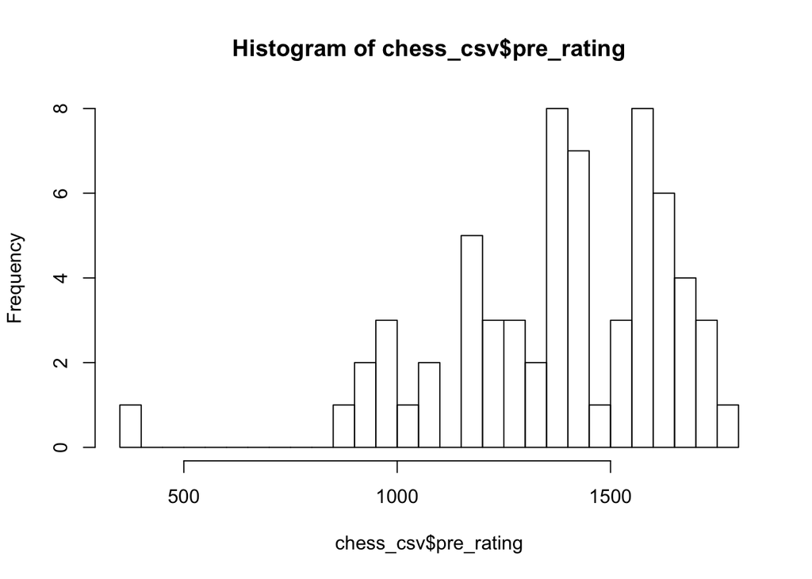

```r
hist(chess_csv$pre_rating, breaks = 50)
```

The distribution is multimodal, left skewed, and centered around 1400. According to some quick online research, this is right in line with the USCF median, and a bit higher than the USCF mean.